# Homework-1

Exercise 2:

Create a scatterplot. Put hwy on the x-axis and cty on the y-axis. Describe what you notice. Is there a relationship between hwy and cty? What does this mean?

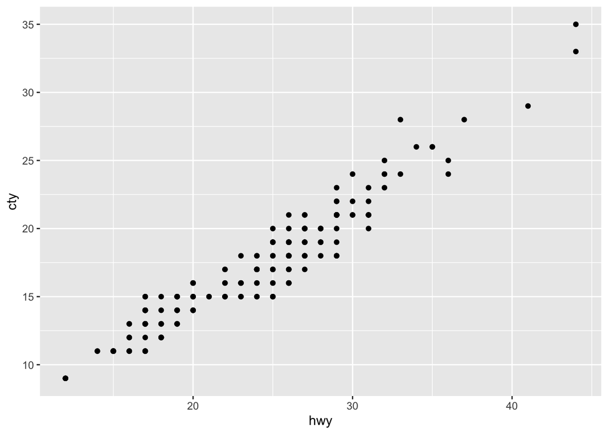

```r
ggplot(mpg, aes(y = cty,x = hwy)) + geom_point()
```

The plot shows an obvious increasing linear relationship between the variables hwy and cty. I am assuming cty stands for miles per gallon when driven in the city. This means that a vehicle with a higher hwy mpg will likely have a higher cty mpg than other cars as well.

Exercise 3:

Make a bar plot of manufacturer. Flip it so that the manufacturers are on the y-axis. Order the bars by height. Which manufacturer produced the most cars? Which produced the least?

```r
library(data.table)
```

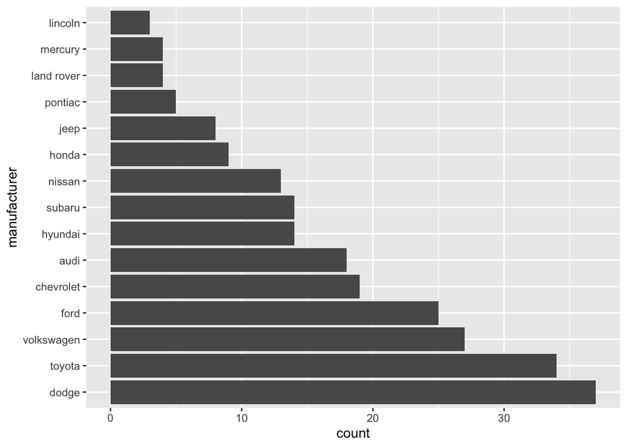

```r
data <- mpg
df <- data.table(mpg)

df[,manufacturer := as.factor(manufacturer)]


ggplot(mpg,aes(y = fct_infreq(manufacturer))) +
    geom_bar(stat = 'count') + ylab('manufacturer')
```

```r
# reordering process learned at: https://www.roelpeters.be/reorder-ggplot2-bar-chart-by-count/
```

Dodge produced the most cars, while Lincoln produced the least.

Exercise 4: Make a box plot of hwy, grouped by cyl. Do you see a pattern? If so, what?

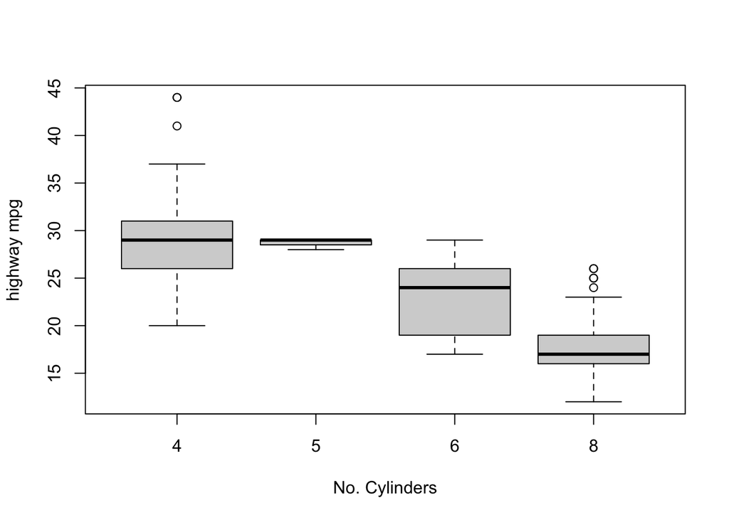

```r
boxplot(mpg$hwy ~ mpg$cyl, xlab = "No. Cylinders", ylab = "highway mpg")
```

It seems that as the number of cylinders increases, the average, maximum,and minimum values for highway mpg generally decrease.

Exercise 5:

Use the corrplot package to make a lower triangle correlation matrix of the mpg dataset. (Hint: You can find information on the package here.)

Which variables are positively or negatively correlated with which others? Do these relationships make sense to you? Are there any that surprise you?

```r
str(mpg)
```

```
## tibble [234 × 11] (S3: tbl_df/tbl/data.frame)
##  $ manufacturer: chr [1:234] "audi" "audi" "audi" "audi" ...
##  $ model       : chr [1:234] "a4" "a4" "a4" "a4" ...
##  $ displ       : num [1:234] 1.8 1.8 2 2 2.8 2.8 3.1 1.8 1.8 2 ...
##  $ year        : int [1:234] 1999 1999 2008 2008 1999 1999 2008 1999 1999 2008 ...
##  $ cyl         : int [1:234] 4 4 4 4 6 6 6 4 4 4 ...
##  $ trans       : chr [1:234] "auto(l5)" "manual(m5)" "manual(m6)" "auto(av)" ...
##  $ drv         : chr [1:234] "f" "f" "f" "f" ...
##  $ cty         : int [1:234] 18 21 20 21 16 18 18 18 16 20 ...
##  $ hwy         : int [1:234] 29 29 31 30 26 26 27 26 25 28 ...
##  $ fl          : chr [1:234] "p" "p" "p" "p" ...
##  $ class       : chr [1:234] "compact" "compact" "compact" "compact" ...
```

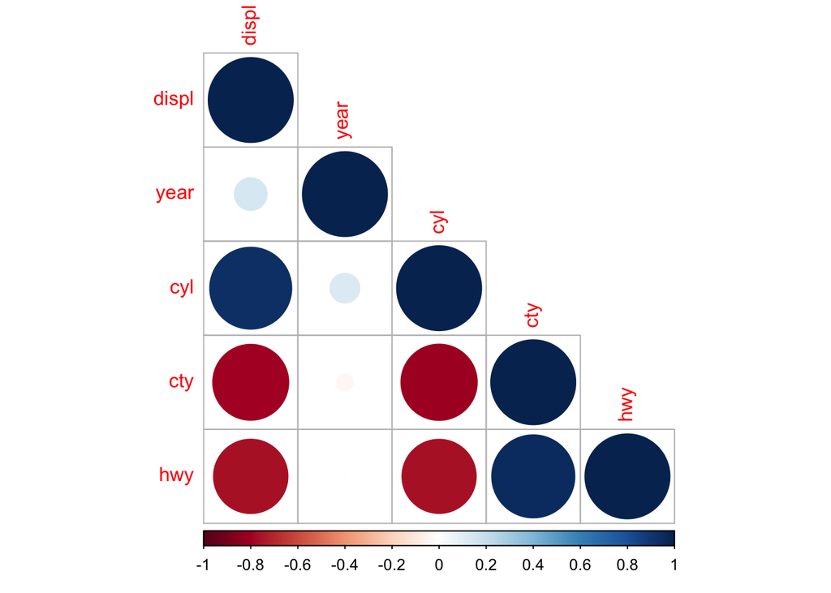

```r
corr <- cor(mpg[c('displ', 'year', 'cyl', 'cty', 'hwy')])

corrplot(corr, type = 'lower')
```

For exercise 5, I decided to include only the variables that were of a numeric type. Following are the pairs of positive and negative correlations, with perceived reasons for correlation.

Pairs: + correlated: (hwy, cty) - a vehicles city mpg will be higher if its hwy mpg is higher (cyl, displ) - as the number of cylinders increases, so does the displacement (generally)

- coorrelated: (cty, displ) - the larger an engine’s displacement, the lower mpg (generally) (hwy, displ) - the larger an engine’s displacement, the lower mpg (generally) (cty, cyl) - the more cylinders in an engine, the lower its mpg (generally) (hwy, cyl) - the more cylinders in an engine, the lower its mpg (generally)

231 Students Only: Exercise 6:

Recreate the following graphic, as closely as you can. Hint: Use the ggthemes package.

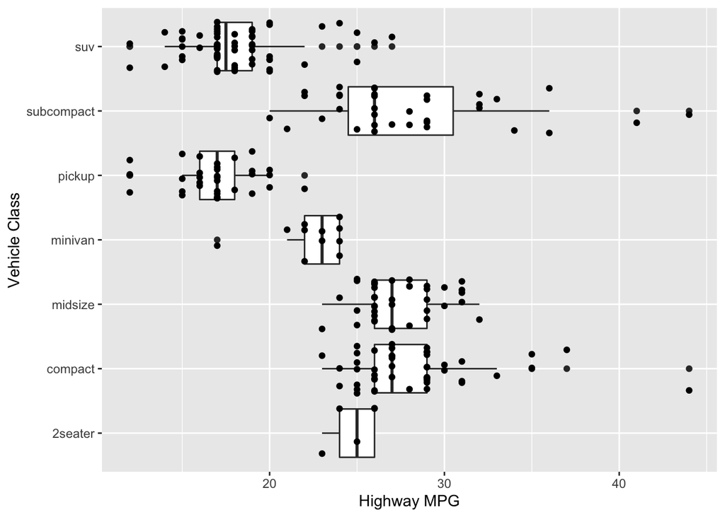

```r
ggplot(mpg, aes(x = hwy, y = class)) + geom_boxplot() + geom_jitter(width = 0) + xlab('Highway MPG') + ylab('Vehicle Class')
```

Exercise 7

Recreate the following graphic.

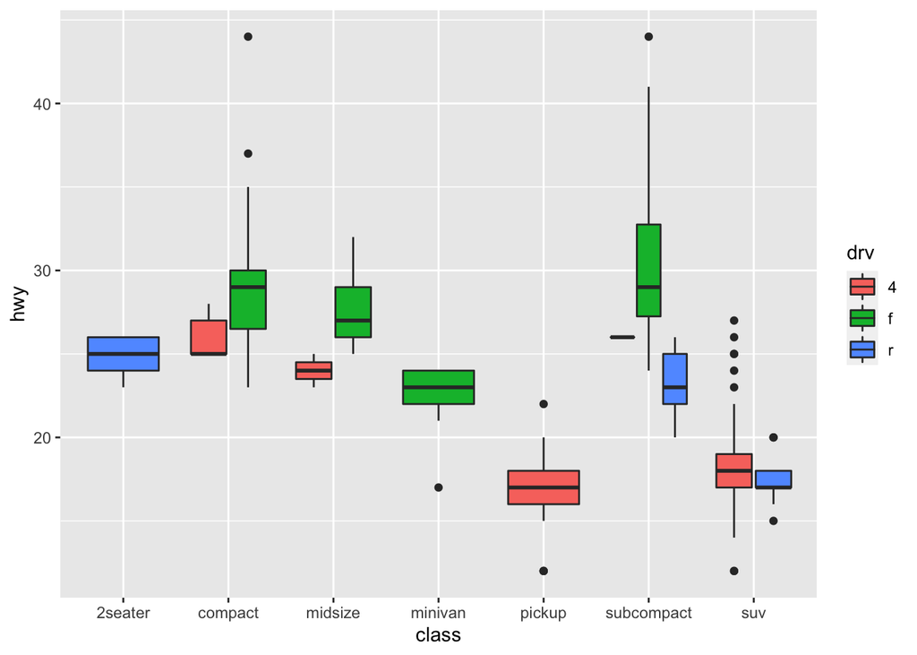

```r
ggplot(mpg, aes(x = class, y = hwy, fill = drv)) + geom_boxplot()
```

Exercise 8

Recreate the following graphic.

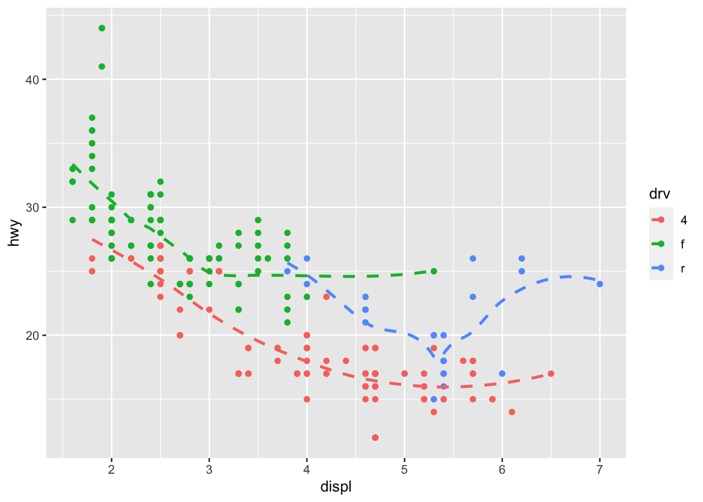

```r
ggplot(mpg, aes(x = displ, y = hwy, color = drv)) + geom_point() + geom_smooth(linetype = 'dashed', se = FALSE)
```